# Weather data exploration

# Setup and load data

```r
library(tidyverse)
library(ggplot2)
library(lubridate)
library(GGally) # for ggpairs to explore correlations
library(psych) # for pairplots to explore correlations
```

```r
daily_energy_weather <- read_csv("../4_cleaned_data/daily_energy_weather_clean.csv")
daily_energy_weather_all <- read_csv("../4_cleaned_data/daily_energy_weather_all.csv") # w/out hholds removed
# weather only to look simply at this data (by day)
daily_weather <- read_csv("../4_cleaned_data/daily_weather_clean.csv")
```

## About the weather observations

What are the units? See kaggle: https://www.kaggle.com/datasets/emmanuelfwerr/london-weather-data

- date - recorded date of measurement - (int)
- cloud_cover - cloud cover measurement in oktas - (float)
- sunshine - sunshine measurement in hours (hrs) - (float)
- global_radiation - irradiance measurement in Watt per square meter (W/m2) - (float)
- max_temp - maximum temperature recorded in degrees Celsius (°C) - (float)
- mean_temp - mean temperature in degrees Celsius (°C) - (float)
- min_temp - minimum temperature recorded in degrees Celsius (°C) - (float)
- precipitation - precipitation measurement in millimeters (mm) - (float)
- pressure - pressure measurement in Pascals (Pa) - (float)
- snow_depth - snow depth measurement in centimeters (cm) - (float)

### Cloud cover

Cloud cover measured in oktas: “Cloud cover is measured on an eight point scale, 0 Oktas being clear sky , one Octa being 1/8 of the sky covered in cloud, and so on up to 8 Oktas - completely overcast.” – https://www.sserc.org.uk/wp-content/uploads/2012/04/Resource-2_2-Measuring-Cloud-Cover.pdf

### Sunshine hours

May be alias with temperature and radiation; higher sunshine hours meaning higher temps and maybe also higher solar energy generation for any households with solar panels (note we do not have this information so cannot exclude this)

### Global radiation

Global radiation: “Solar irradiance is the power per unit area (surface power density) received from the Sun in the form of electromagnetic radiation in the wavelength range of the measuring instrument.” – https://en.wikipedia.org/wiki/Solar_irradiance#:~:text=The%20SI%20unit%20of%20irradiance,or%2041%2C840%20J%2Fm2.

May be related to temperature and sunshine hours, also may indicate how much energy generated from household solar panels, if any, and thus not drawn from the grid (and therefore assume not included in smart energy measurement of consumption).

### Temperature

max, mean and min for each day

Note 0 here is not ture 0, it represented 0 degrees Celsius (freezing point of water)

### Precipitation

measurement in millimeters (mm) - so here 0 means no precipitation

Maybe weather days mean cooler days mean more heating - so check for aliases with energy usage.

Maybe wetter days also mean more tumble dryer usage, or shower/hairdryer if got wet outside.

Could convert to yes/no if interesting to do so.

### Pressure

Air pressure measurement in Pascals (Pa).

Note: standard atmospheric pressure on Earth is 101,325 Pa (https://en.wikipedia.org/wiki/Pascal_(unit)) – so could reframe to higher/lower than 1 atm_press or recode units to number of atmospheric pressure units.

Note raw pascals is currently v different scale (100,000s) to other units in this df.

### Snow depth

measurement in centimeters (cm) - so 0 is true 0 here (meaning no snow).

May be useful to convert to snow yes/no, since it is a rare occurrence, and depth may not make much difference beyond the temp measurement (any snow means it’s a cold day).

## Skim

```r
view(skimr::skim(daily_weather))
```

1 missing value for cloud_cover

- Temperatures (min, mean, max) and pressure values look normally distributed, max_temp most so, mean_temp still looks ok, min_temp might be a little right skewed
- Cloud cover is left skewed (i.e. lots at higher values, long beginning tail)
- Rest (sunshine, radiation, precipitation, snow_depth) are right skewed (i.e. lots a lower values, long ending tail)

Scales are different: 1s, 10s, and pressure is in 100,0000s

min values of 0: kWh, cloud cover, sunshine, precipitation, snow_depth – 0 would be a real value for all of these, see units below.

## [ ] Assertions about data

Improve cleaning/preparations steps for weather data

Include assertions to stop or warn if data is not as expected:

- numeric data:
  - cloud cover >=0 & <= 8 (okta scale is set to 0-8)
  - sunshine >=0 & <= 24 (can only be 0 - 24 hours)
  - *_temp >= -20 & <= 50 (i.e. use reasonable cutoffs for temperature in UK)
  - DO NOT USE THESE: max_temp >= min_temp & max_temp >= mean_temp & mean_temp >= min_temp
- date format:
  - date: >= start_date & <= end_date (as specified)

### Cleaning steps for weather data

Other cleaning steps:

- add quality col to note the days where
  - mean_temp > max_temp (it shouldn’t be!)
  - min_temp > max_temp
- convert pressure to atm pressure units (i.e. / 101,325 Pa) - *no need, not using in this iteration*
- add var for snow yes/no
- add var for precipitation yes/no
- if not using season/month, could add temp_levels factor (low, medium, high - work out how) - *not doing in this iteration*

```r
start_date <- min(daily_energy_weather_all$date)
start_date
```

```
[1] "2011-12-01"
```

```r
end_date <- max(daily_energy_weather_all$date)
end_date
```

```
[1] "2014-02-27"
```

```r
daily_weather_trim <- read_csv("../3_raw_data/london_weather.csv") %>%
  janitor::clean_names() %>%
  mutate(date = ymd(date)) %>%
  filter(as_date(date) >= start_date & as_date(date) <= end_date)
```

```r
daily_weather_clean <- daily_weather_trim %>%
  # add quality col to note the days where (1) mean_temp > max_temp
  # and (2) min_temp > max_temp
  mutate(temp_qual = case_when(
    mean_temp > max_temp & min_temp > max_temp ~ "warning: max temp less than min temp and mean temp",
    mean_temp > max_temp ~ "warning: max temp less than mean temp",
    min_temp > max_temp ~ "warning: max temp less than min temp",
    .default = NA_character_
  )) %>%
  # add var for snow yes/no
  mutate(snow_tf = if_else(snow_depth > 0, T, F), .before = snow_depth) %>%
  # add var for precipitation yes/no
  mutate(precipitation_tf = if_else(precipitation > 0, T, F), .before = precipitation)
```

```r
daily_weather_clean %>%
  summarise(count = n(), .by = temp_qual)
```

| temp_qual | count |
| --- | --- |
| NA | 756 |
| warning: max temp less than mean temp | 50 |
| warning: max temp less than min temp and mean temp | 14 |

```r
daily_weather_clean %>%
  select(snow_tf, snow_depth) %>%
  summarise(snowy_days = n(), .by = snow_tf)
```

| snow_tf | snowy_days |
| --- | --- |
| FALSE | 810 |
| TRUE | 10 |

```r
daily_weather_clean %>%
  summarise(rainy_days = n(), .by = precipitation_tf)
```

| precipitation_tf | rainy_days |
| --- | --- |
| TRUE | 446 |
| FALSE | 374 |

Summary from these cleaning steps:

**include in write-up**

- Data quality note: 64 dates where max temp < mean temp, of which 14 dates where max temp also less than min temp.
- 10 days with snow, 810 days without
- 446 days with precipitation, out of 820

### [ ] Cleaning steps for energy data

In energy data prep:

- check for any NA_character_ <– would have been created through my recoding steps
- assert kwh >= 0 & kwh < 500 (reasonable upper limit cutoff)
- assert date >= start_date & <= end_date (as specified)

### check data quality

Assertions above pass, except for the following, for which add data quality cols to note these!

- 64 days where max_temp < mean_temp value
- 14 days where min_temp > max_temp
- 1 day where min == max, but mean is larger

```r
daily_weather %>%
  filter(min_temp == max_temp)
```

# Explore correlations

Use `daily_energy_weather` for cleaned households and `daily_energy_weather_all` to include all households (e.g. with lots of 0s, in case of solar panels)

*Note: ggpairs or pairs.panels not running right now*

## kwh ~ mean_temp

```r
daily_energy_weather_all %>%
  distinct(lc_lid)
```

| lc_lid |
| --- |
| MAC000002 |
| MAC000003 |
| MAC000004 |
| MAC000005 |
| MAC000006 |
| MAC000007 |
| MAC000008 |
| MAC000009 |
| MAC000010 |
| MAC000011 |

[output cut: 990 more lines]

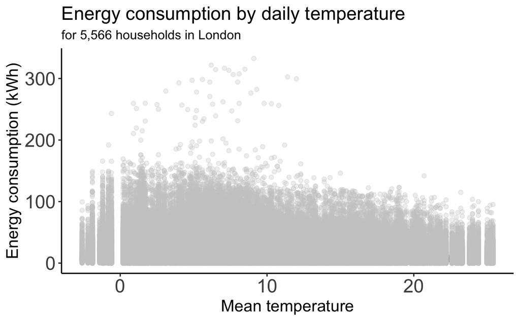

```r
daily_energy_weather_all %>%
  ggplot() +
  geom_point(aes(x = mean_temp, y = kwh), colour = "grey80", alpha = 0.3) +
  labs(y = "Energy consumption (kWh)", x = "Mean temperature",
       title = "Energy consumption by daily temperature",
       subtitle = "for 5,566 households in London") +
  theme_cc_final_project()
```

There are points with much higher usages as lower temperatures - are they the same household?

```r
daily_energy_weather_all %>%
  filter(kwh > 150) %>%
  ggplot() +
  geom_point(aes(x = mean_temp, y = kwh, colour = lc_lid))
```

They are not the same households, but are only a small number (22) of the 5,500 total (note: this is the uncleaned dataset)

Check also with the cleaned dataset

```r
daily_energy_weather %>%
  ggplot() +
  geom_point(aes(x = mean_temp, y = kwh))
```

```r
daily_energy_weather %>%
  filter(kwh > 150) %>%
  ggplot() +
  geom_point(aes(x = mean_temp, y = kwh, colour = lc_lid))
```

We’ve only lost one household from the cleaning step

## kwh ~ sunshine

```r
daily_energy_weather_all %>%
  ggplot() +
  geom_point(aes(x = sunshine, y = kwh))
```

General trend of lower kWh as number of sunshine hours increases

Some households with much higher use (>150 kwh) when sunshine less (<8 hours) – remember sunshine hours might be factor of season

```r
daily_energy_weather_all %>%
  filter(kwh > 150) %>%
  ggplot() +
  geom_point(aes(x = sunshine, y = kwh, colour = lc_lid))
```

## kwh ~ radiation

```r
daily_energy_weather_all %>%
  ggplot() +
  geom_point(aes(x = global_radiation, y = kwh))
```

Same pattern… high use on low radiation days

Find any middle users who drop to zero at high radiation (consider solar panels)?

```r
daily_energy_weather_all %>%
  filter(kwh > 150) %>%
  ggplot() +
  geom_point(aes(x = global_radiation, y = kwh, colour = lc_lid))
```

## kwh ~ precipitation

```r
daily_energy_weather_all %>%
  ggplot() +
  geom_point(aes(x = precipitation, y = kwh))
```

Most days have low precipitation, some high values on these days. No obvious pattern for energy usage at higher precipitation.

Suggest dropping precipitation.

## kwh ~ snow_depth

```r
daily_energy_weather_all %>%
  ggplot() +
  geom_point(aes(x = snow_depth, y = kwh))
```

Most days have no snow… filter for > 0

```r
daily_energy_weather_all %>%
  filter(snow_depth > 0) %>%
  mutate(snow_depth = factor(snow_depth)) %>%
  ggplot() +
  geom_boxplot(aes(x = snow_depth, y = kwh))
```

No correlation here, drop snow_depth

Look at snow yes/no:

```r
daily_energy_weather_all %>%
  mutate(snow = if_else(snow_depth == 0, F, T)) %>%
  ggplot() +
  geom_boxplot(aes(x = snow, y = kwh))
# note this does not account for within-household relationship!
```

Would need to look at kWh change based on snow yes/no

## kwh ~ pressure

```r
daily_energy_weather_all %>%
  ggplot() +
  geom_point(aes(x = pressure, y = kwh))
```

No discernible neg/pos correlation with kWh here, suggest dropping pressure

## kwh ~ cloud_cover

Note cloud cover is not continuous numeric, it’s a scale system, make it a factor…

```r
daily_energy_weather_all %>%
  mutate(cloud_cover = factor(cloud_cover)) %>%
  ggplot() +
  geom_boxplot(aes(x = cloud_cover, y = kwh))
```

No discerinble pattern here

## kwh ~ min_temp

```r
daily_energy_weather_all %>%
  ggplot() +
  geom_point(aes(x = min_temp, y = kwh))
```

Similar pattern to mean_temp

## kwh ~ max_temp

```r
daily_energy_weather_all %>%
  ggplot() +
  geom_point(aes(x = max_temp, y = kwh))
```

Again similar pattern to mean_temp

# understand weather and month correlations

e.g. sunshine hours, radiation, mean_temp

```r
daily_weather %>%
  ggplot(aes(x = sunshine, y = mean_temp)) +
  geom_point() +
  geom_smooth()
```

Default line of best fit is not straight, but typically as sunshine hours increase, mean_temp increases

```r
daily_weather %>%
  ggplot(aes(x = sunshine, y = mean_temp)) +
  geom_point() +
  geom_smooth(method = lm)
```

Clearly a positive correlation here, so take care with using mean_temp and sunshine hours

Why are there values with 0 sunshine hours? Look at cloud cover…

```r
daily_weather %>%
  ggplot(aes(y = sunshine, x = cloud_cover)) +
  geom_point()
```

There are low numbers of sunshine hours as cloud cover gets high – suggests the sunshine hours value is more to do with direct sunshine rather than daylight.

Check sunshine hours v radiation radiation v cloud_cover too

```r
daily_weather %>%
  ggplot(aes(x = sunshine, y = global_radiation)) +
  geom_point() +
  geom_smooth()
```

Very clear positive correlation here, more sunshine hours = higher radiation

```r
daily_weather %>%
  ggplot(aes(y = global_radiation, x = cloud_cover)) +
  geom_point()
```

## time ~ energy

### month ~ energy

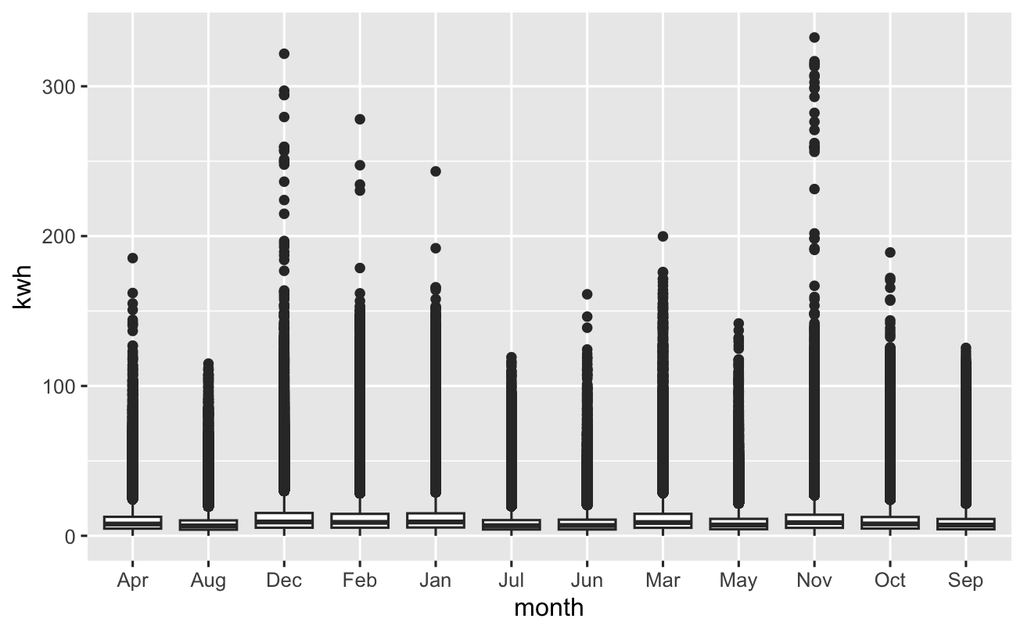

```r
daily_energy_weather %>%
  ggplot(aes(x = month, y = kwh)) +
  geom_boxplot()
```

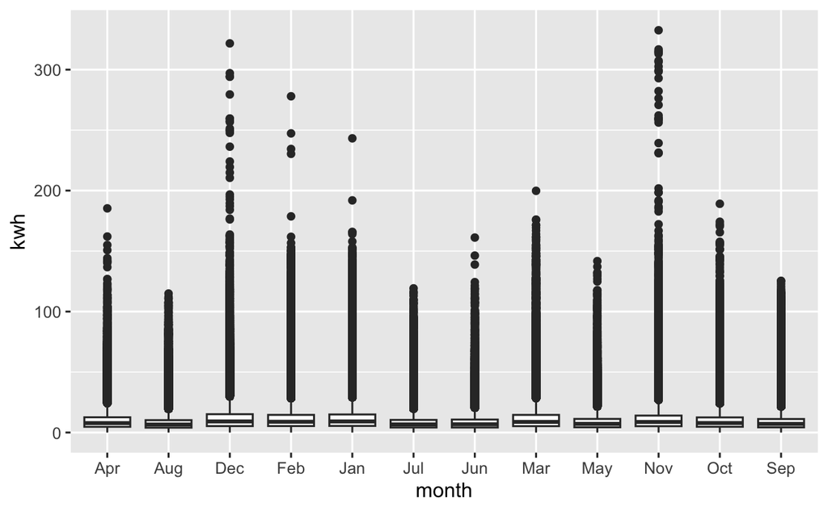

```r
daily_energy_weather_all %>%
  ggplot(aes(x = month, y = kwh)) +
  geom_boxplot()
```

(Note cleaned only has slight difference to all households)

Very long tail in Q3-Q4 range, making it harder to see medians – but note energy is higher in Nov-Mar, lower in May - Aug.

### season ~ energy

```r
daily_energy_weather %>%
  ggplot(aes(x = season, y = kwh)) +
  geom_boxplot()

daily_energy_weather_all %>%
  ggplot(aes(x = season, y = kwh)) +
  geom_boxplot()
```

Does look like summer/winter effect, winter higher energy spend (spring/fall between the two)

### weekday type ~ energy

```r
daily_energy_weather %>%
  ggplot(aes(x = weekend, y = kwh)) +
  geom_boxplot()

daily_energy_weather_all %>%
  ggplot(aes(x = weekend, y = kwh)) +
  geom_boxplot()
```

Hard to discern a difference here, look with season too

```r
daily_energy_weather %>%
  filter(season != "Spring/Autumn") %>%
  ggplot(aes(x = weekend, y = kwh)) +
  geom_boxplot() +
facet_wrap(~ season)

daily_energy_weather_all %>%
  ggplot(aes(x = weekend, y = kwh)) +
  geom_boxplot() +
facet_wrap(~ season)
```

```r
daily_energy_weather %>%
  filter(kwh < 100) %>% # zoom in
  ggplot() +
  geom_histogram(aes(x = kwh), bins = 100) +
facet_wrap(weekend ~ season, ncol = 3)
```

Seasonal decomposition suggest levels were higher on the weekend days. I’m not convinced there is a weekend effect here! At least, cannot see it as global effect. Still worth exploring if there is this for individual households.

## time x weather

### month ~ weather

```r
# same time format changes as in the processed household energy data (see script)
# use weather only df here to have one row per day, no repeats for diff households
daily_weather <- daily_weather %>%
  mutate(month = month(date, label = TRUE), .after = date) %>%
  mutate(wday = wday(date, label = TRUE), .after = month) %>%
  mutate(weekend = if_else(wday %in% c("Sat", "Sun"), T, F), .after = wday) %>%
  mutate(quarter = quarter(date, type = "date_first", fiscal_start = 12), .after = month) %>%
  mutate(yearseason = case_when(
    quarter == "2011-09-01" ~ "Autumn 2011",
    quarter == "2011-12-01" ~ "Winter 2011",
    quarter == "2012-03-01" ~ "Spring 2012",
    quarter == "2012-06-01" ~ "Summer 2012",
    quarter == "2012-09-01" ~ "Autumn 2012",
    quarter == "2012-12-01" ~ "Winter 2012",
    quarter == "2013-03-01" ~ "Spring 2013",
    quarter == "2013-06-01" ~ "Summer 2013",
    quarter == "2013-09-01" ~ "Autumn 2013",
    quarter == "2013-12-01" ~ "Winter 2013",
    .default = NA_character_
  ), .after = quarter) %>%
  mutate(yearseason = factor(yearseason, levels = c(
    "Autumn 2011", "Winter 2011", "Spring 2012", "Summer 2012",
    "Autumn 2012", "Winter 2012", "Spring 2013", "Summer 2013",
    "Autumn 2013", "Winter 2013"
    ))) %>%
  mutate(season = case_when(
    str_detect(yearseason, "Winter") ~ "Winter",
    str_detect(yearseason, "Summer") ~ "Summer",
    str_detect(yearseason, "Spring|Autumn") ~ "Spring/Autumn",
    .default = NA_character_
  ), .after = month)

daily_weather
```

| date | month | season | quarter | yearseason | wday | weekend | cloud_cover | sunshine | global_radiation | max_temp | mean_temp | min_temp | precipitation_tf | precipitation | pressure | snow_tf | snow_depth | temp_qual |
| --- | --- | --- | --- | --- | --- | --- | --- | --- | --- | --- | --- | --- | --- | --- | --- | --- | --- | --- |
| 2011-12-01 | Dec | Winter | 2011-12-01 | Winter 2011 | Thu | FALSE | 7 | 0.7 | 22 | 11.4 | 9.5 | 8.0 | TRUE | 5.0 | 100710 | FALSE | 0 | NA |
| 2011-12-02 | Dec | Winter | 2011-12-01 | Winter 2011 | Fri | FALSE | 3 | 4.1 | 41 | 11.9 | 6.8 | 2.1 | TRUE | 0.8 | 101220 | FALSE | 0 | NA |
| 2011-12-03 | Dec | Winter | 2011-12-01 | Winter 2011 | Sat | TRUE | 7 | 1.2 | 25 | 9.5 | 7.7 | 3.4 | FALSE | 0.0 | 100360 | FALSE | 0 | NA |
| 2011-12-04 | Dec | Winter | 2011-12-01 | Winter 2011 | Sun | TRUE | 6 | 0.0 | 13 | 7.6 | 8.2 | 6.9 | TRUE | 0.6 | 100120 | FALSE | 0 | warning: max temp less than mean temp |
| 2011-12-05 | Dec | Winter | 2011-12-01 | Winter 2011 | Mon | FALSE | 1 | 3.1 | 35 | 9.0 | 4.8 | 1.9 | FALSE | 0.0 | 100610 | FALSE | 0 | NA |
| 2011-12-06 | Dec | Winter | 2011-12-01 | Winter 2011 | Tue | FALSE | 2 | 0.7 | 21 | 9.8 | 5.7 | 2.4 | FALSE | 0.0 | 100740 | FALSE | 0 | NA |
| 2011-12-07 | Dec | Winter | 2011-12-01 | Winter 2011 | Wed | FALSE | 2 | 6.0 | 48 | 13.2 | 6.8 | 3.8 | FALSE | 0.0 | 100890 | FALSE | 0 | NA |
| 2011-12-08 | Dec | Winter | 2011-12-01 | Winter 2011 | Thu | FALSE | 7 | 0.0 | 13 | 8.2 | 8.0 | 2.7 | TRUE | 1.0 | 101070 | FALSE | 0 | NA |
| 2011-12-09 | Dec | Winter | 2011-12-01 | Winter 2011 | Fri | FALSE | 1 | 4.8 | 42 | 6.6 | 5.9 | 3.5 | FALSE | 0.0 | 101070 | FALSE | 0 | NA |
| 2011-12-10 | Dec | Winter | 2011-12-01 | Winter 2011 | Sat | TRUE | 1 | 5.3 | 44 | 9.2 | 2.6 | -1.4 | FALSE | 0.0 | 101570 | FALSE | 0 | NA |

[output cut: 810 more lines]

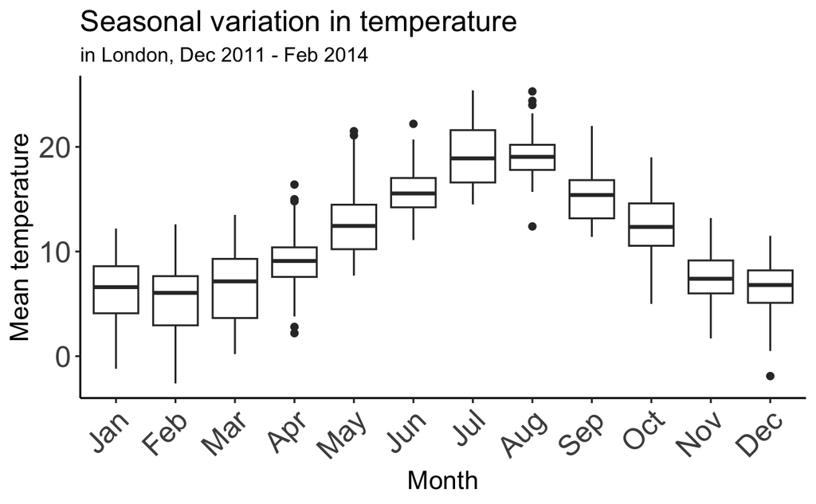

```r
daily_weather %>%
  ggplot(aes(x = month, y = mean_temp)) +
  geom_boxplot() +
  labs(x = "Month", y = "Mean temperature",
       title = "Seasonal variation in temperature",
       subtitle = "in London, Dec 2011 - Feb 2014") +
  theme_cc_final_project() +
  theme(axis.text.x = element_text(angle = 45, hjust = 1))
```

So mean temperature is a factor of month, higher temps in summer, lower in winter.

Could use January and July or Dec-Feb and June - Aug as set time periods to look at individually

```r
# sunshine
daily_weather %>%
  ggplot(aes(x = month, y = sunshine)) +
  geom_boxplot()
```

Sunshine relationship is less clearly by month - although lower in Dec/Jan, highest in July

```r
daily_weather %>%
  ggplot(aes(x = month, y = global_radiation)) +
  geom_boxplot()
```

Radiation is a factor of month too, similar to temp

```r
daily_weather %>%
  ggplot(aes(x = month, y = cloud_cover)) +
  geom_boxplot()
```

Less a seasonal pattern, note cloud cover looks lowest in July/Aug/Sept

```r
daily_weather %>%
  filter(snow_depth > 0) %>%
  ggplot(aes(x = month, y = snow_depth)) +
  geom_boxplot()
```

Only Jan and Feb have any snow, maybe more snow in Jan than Feb

Only useful to look at snow_Depth ~ kwh in Jan/Feb months - but even filtering for only days with some snow –> no correlations with kWh (se bloxplots above)

### season ~ weather

```r
daily_weather %>%
  ggplot(aes(x = yearseason, y = mean_temp)) +
  geom_boxplot() +
  theme(axis.text = element_text(angle = 45))
```

```r
daily_weather %>%
  ggplot(aes(x = season, y = mean_temp)) +
  geom_boxplot()
```

Clear seasonal variation in temperature

```r
daily_weather %>%
  ggplot(aes(x = yearseason, y = cloud_cover)) +
  geom_boxplot() +
  theme(axis.text = element_text(angle = 45))
```

Less obvious differences, see lowest cloud_cover in Summer 2013

```r
daily_weather %>%
  ggplot(aes(x = yearseason, y = sunshine)) +
  geom_boxplot() +
  theme(axis.text = element_text(angle = 45))
```

Generally higher in summer, lower in winter, but variable (eg spring 2012 == summer 2012, Winter 2012 particularly low)

```r
daily_weather %>%
  ggplot(aes(x = yearseason, y = global_radiation)) +
  geom_boxplot() +
  theme(axis.text = element_text(angle = 45))
```

Very clear seasonal variation in radiation, higher in spring/summer, lower in autumn/winter

Summary of seasonal effects:

- temperature - yes, very clear, summer high, winter low
- cloud_cover - not clearly, but dip in summer 2013
- sunshine - yes, but varies year on year
- global_radiation - yes, very clear, spring/summer high, autumn/winter low

### weekday type ~ weather

Assume it’s not related

```r
daily_weather %>%
  ggplot(aes(x = weekend, y = mean_temp)) +
  geom_boxplot()
```

```r
daily_weather %>%
  ggplot(aes(x = weekend, y = global_radiation)) +
  geom_boxplot()
```

```r
daily_weather %>%
  ggplot(aes(x = weekend, y = sunshine)) +
  geom_boxplot()
```

```r
daily_weather %>%
  ggplot(aes(x = weekend, y = cloud_cover)) +
  geom_boxplot()
```

Clearly no relationship between weather and weekday type (weekend or not).

## summary of predictors to consider

Weather values to consider:

- temp (use mean, drop min/max)
- sunshine hours (use instead of radiation or cloud_cover (aliases); check corr with month too and beware)

Drop pressure, precipitation

Note lots of factors are inter-related, these are **not independent variables**.

Potential aliases with date / month / season:

- temperature and radiation - clear seasonal pattern, month-by-month
- maybe sunshine - but less distinct
- cloud_cover lowest in Jul/Aug - less of a transitional pattern though
- snow only happens in Jan/Feb

Use these as descriptive elements about energy use - only factor in temp and sunshine hours in potential models – avoid aliasing with month

Time factors as predictos:

- month or season, if not using weather factors
- weekday tyep (weekend T/F) - to see if individual households change schedules

## work out predictors that summarise household behaviour

Weather values to consider:

- mean_temp
- sunshine

But beware seasonal relationship. Can include with weekend y/n, not with month.

So can try:

- year-round predictors with temp, sunshine, weekend OR month, weekend
- or do winter-only model, summer-only models - and don’t include month

–> make predictors that cover both scenarios (e.g. winter variation)

Try to reduce to 1 row per household, with calculated variables explaining relationship with these predictors

e.g. find slope from high to low weather value, and look at change in kwh (as % change?)

i.e. find the coefficients for lm per household? Have a look at a few individual households…

Simpler:

- mean/median(winter 2013 (–> Feb 2014))
- mean/median(summer 2013)
- mean/median(July 2013) - as most recent (and most number households)
- mean/median(January 2014) - as most recent (and most number households)
- mean(summer) - mean(winter) kwh as summer/winter difference
- max(winter) - min(winter) as within-winter variation (or iqr)
- max(summer) - min(summer) as within-summer variation (or iqr)
- mean of top 10 highest kwh – helps reduce effect of any really big values
- mean of bottom 10 non-zero kwh – filter out 0s first
- number recorded days (so can eliminate if needed)
- % recorded days with 0 kWh (so can eliminate if needed)
- % recorded days with >150 kWh (e.g.)
- relative winter weekend diff (% change): 100 * avg(weekendTwinter) - avg(weekendFwinter) / avg(winter) – or use sd or iqr
- relative summer weekend diff: 100 * avg(weekendTwinter) - avg(weekendFwinter) / avg(summer) – or use sd or iqr
- something to do with temp – note potential alias with winter/summer things
- something to do with sunshine – note potential alias with winter/summer things

To aid in colouring plots for exploration, but not for clustering:

- label households with any kWh days > 150 (e.g.) as high users – for colouring plots later
- label households as high/average/low as to how their median kwh falls in with sample median – e.g. use 0-10%, 10-20%,20-50%, 50-80%, 80-90%, 90-100% deciles
- label households with any kWh = 0 days

Instead of winter/summer, could use Jan/July – but figure that energy pattern is likely related to when people switch on heating schedules again, and this is probably more relevant to winter/summer rather than one month, also using only one month reduces the size of the data available. Could include both ways and see which seem to have strongest correlations.

Use 2013/2014 seasons/months as most recent ones (Summer 2013, July 2013, Winter 2013, January 2014), with most number of households. Cleanest data in terms of household behaviour pattern - avoids potential for differing behaviour year-on-year.

## Possible clusters

In summary, look out for:

- high energy consumption at lower temperatures (i.e. >=150 kWh at < 13 degrees C)
- high energy consumption at low sunshine hours - bear in mind relationship to season
- same for radiation

Look at the ~20 households with kwh values higher than 150 kWh – model these individually?

Think about user behaviour: do people adjust their heating according to daily temp? Or do they turn it on when it gets to colder months, and leave it on until it’s spring again - i.e. month and weekend/weekday is more useful as a pattern of heating schedules

Also look for households whoese kwh drops on sunny days (low cloud cover, high sunshine hours, high radiation) - to spot those with solar panels?